# Retail Store Inventory Analysis

Abhijith

2024-10-26

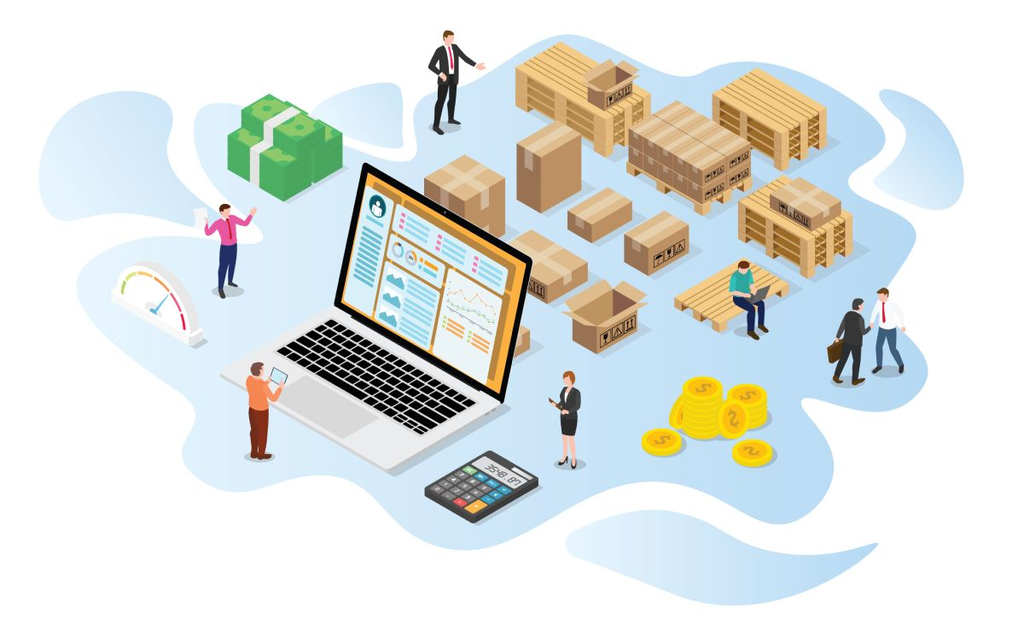

Source: Inventory Analysis.

## Loading the dataset

### Descriptive Statistics

Data Summary: Descriptive statistics for Units_sold, Price, and Revenue give an overview of central tendencies and variability. This basic step is essential to understand the spread and range of key metrics.

```r
# Read the CSV file
data <- read_csv("retail_store.csv")

# Convert 'Date' column to Date and extract the 'Year'
data$Date <- as.Date(data$Date)
data$Year <- year(data$Date)
#data$Year
# Add 'Revenue' column
data$Revenue <- data$Units_sold * data$Price
# Filter out rows where 'Price' and 'Units_sold' are not 0
df <- data %>% filter(Price != 0, Units_sold != 0)

# Data info
str(data)
```

```
## spc_tbl_ [937 × 6] (S3: spec_tbl_df/tbl_df/tbl/data.frame)
##  $ Date      : Date[1:937], format: "2014-01-01" "2014-01-02" ...
##  $ Units_sold: num [1:937] 0 70 59 93 96 145 179 321 125 88 ...
##  $ Stock     : num [1:937] 4972 4902 4843 4750 4654 ...
##  $ Price     : num [1:937] 1.29 1.29 1.29 1.29 1.29 1.29 1.29 1.29 1.09 1.09 ...
##  $ Year      : num [1:937] 2014 2014 2014 2014 2014 ...
##  $ Revenue   : num [1:937] 0 90.3 76.1 120 123.8 ...
##  - attr(*, "spec")=
##   .. cols(
##   ..   Date = col_date(format = ""),
##   ..   Units_sold = col_double(),
##   ..   Stock = col_double(),
##   ..   Price = col_double()
##   .. )
##  - attr(*, "problems")=<externalptr>
```

```r
options(repr.plot.width = 10, repr.plot.height = 4)
# Descriptive statistics for 'Units_sold', 'Price', and 'Revenue'
summary(data[, c("Units_sold", "Price", "Revenue")])
```

```
##    Units_sold         Price          Revenue
##  Min.   :  0.00   Min.   :0.000   Min.   :  0.00
##  1st Qu.: 33.00   1st Qu.:1.290   1st Qu.: 52.32
##  Median : 76.00   Median :1.390   Median :112.23
##  Mean   : 90.53   Mean   :1.593   Mean   :148.23
##  3rd Qu.:127.00   3rd Qu.:1.890   3rd Qu.:207.10
##  Max.   :542.00   Max.   :2.980   Max.   :870.24
```

## Visualizations and Analysis

### Time Series Analysis

Price Over Time: A line plot shows how the Price of products changes over time. Any trends, seasonal patterns, or sudden price spikes or drops are easily visible here.

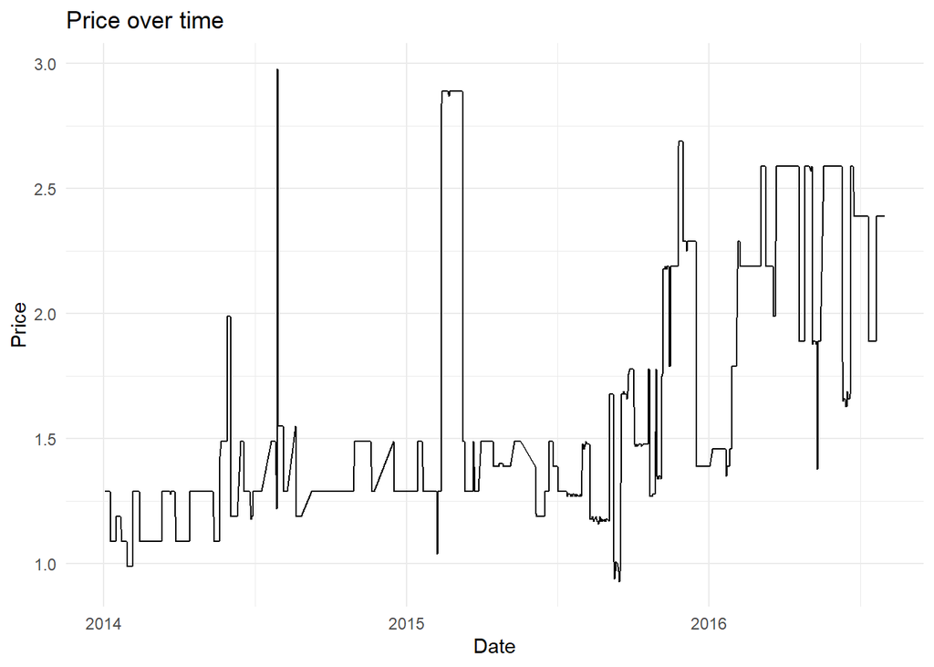

```r
# Visualization - Price over time
ggplot(df, aes(x = Date, y = Price)) +
    geom_line() +
    ggtitle("Price over time") +
    theme_minimal()
```

Sales in Units Over Time: A line plot of Units_sold over time shows fluctuations in demand, helping identify peak sales periods and slower months.

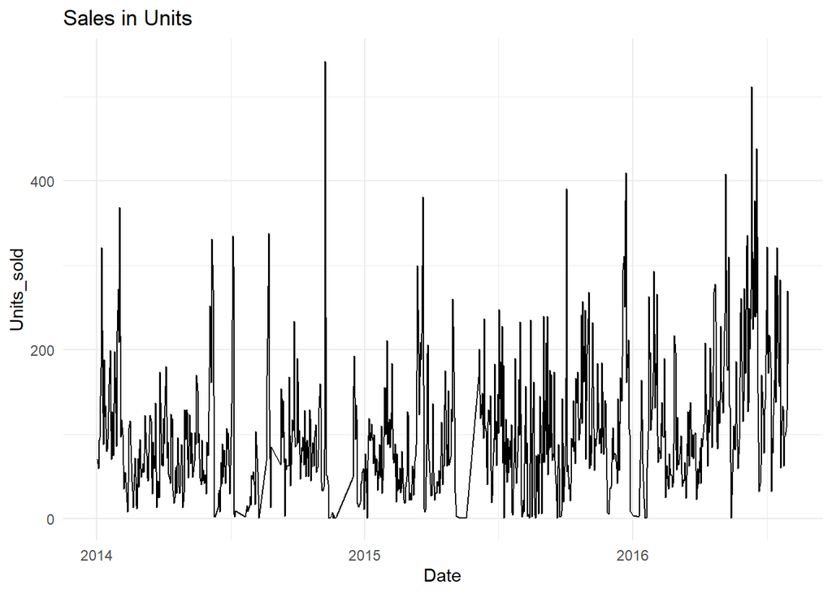

```r
# Visualization - Sales in Units over time
ggplot(df, aes(x = Date, y = Units_sold)) +
  geom_line() +
  ggtitle("Sales in Units") +
  theme_minimal()
```

Sales Revenue Over Time: Revenue over time helps to pinpoint high-revenue periods and indicates possible trends in sales volume combined with pricing.

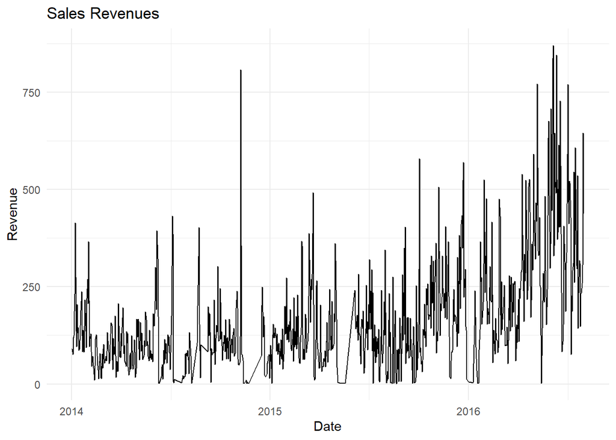

```r
# Visualization - Sales Revenues over time
ggplot(df, aes(x = Date, y = Revenue)) +
  geom_line() +
  ggtitle("Sales Revenues") +
  theme_minimal()
```

### Density Analysis

Density Plots: Price, Stock, Units_sold, and Revenue densities give insights into the distributions of these metrics. For example, if Price density is skewed right, it implies most prices are on the lower end, with a few higher-priced outliers.

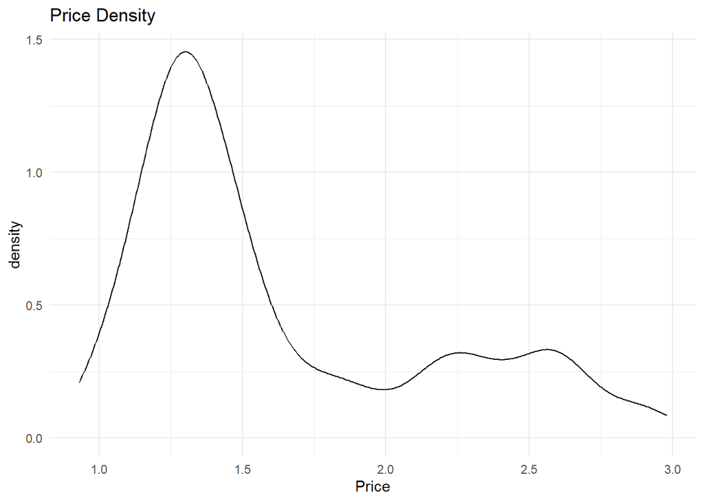

```r
# Density Plots
ggplot(df, aes(x = Price)) +
  geom_density() +
  ggtitle("Price Density") +
  theme_minimal()
```

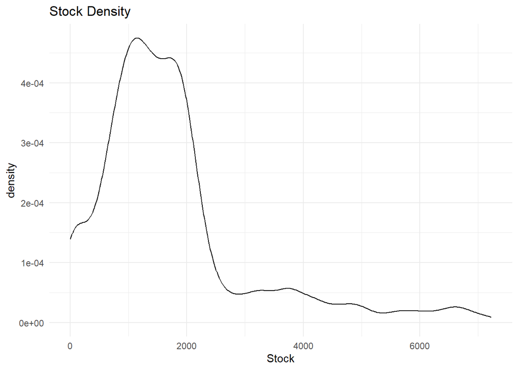

```r
ggplot(df, aes(x = Stock)) +
  geom_density() +
  ggtitle("Stock Density") +
  theme_minimal()
```

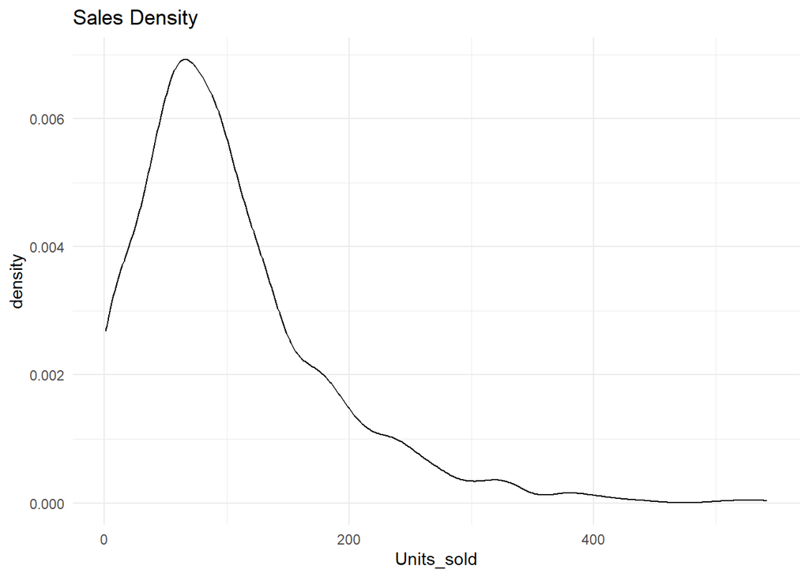

```r
ggplot(df, aes(x = Units_sold)) +
  geom_density() +
  ggtitle("Sales Density") +
  theme_minimal()
```

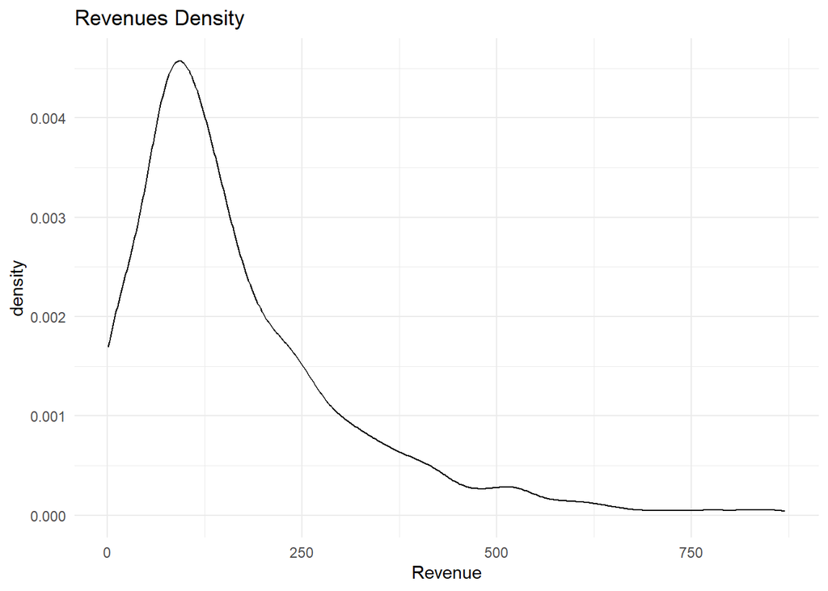

```r
ggplot(df, aes(x = Revenue)) +
  geom_density() +
  ggtitle("Revenues Density") +
  theme_minimal()
```

### Sales and Revenue by Year

Scatter Plot - Revenue vs. Sales by Year: This plot shows how revenues correspond to unit sales, color-coded by year, revealing relationships between these metrics. The scatter pattern can indicate if certain years experienced higher variability or concentration.

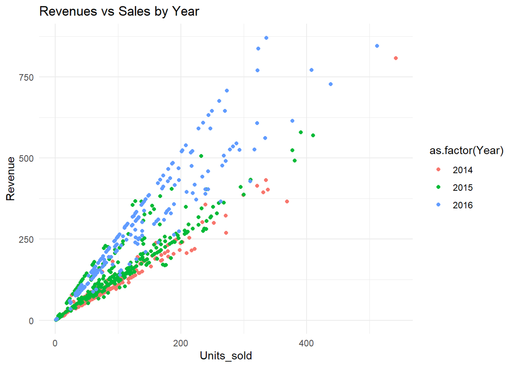

```r
ggplot(df, aes(x = Units_sold, y = Revenue, color = as.factor(Year))) +
  geom_point() +
  ggtitle("Revenues vs Sales by Year") +
  theme_minimal()
```

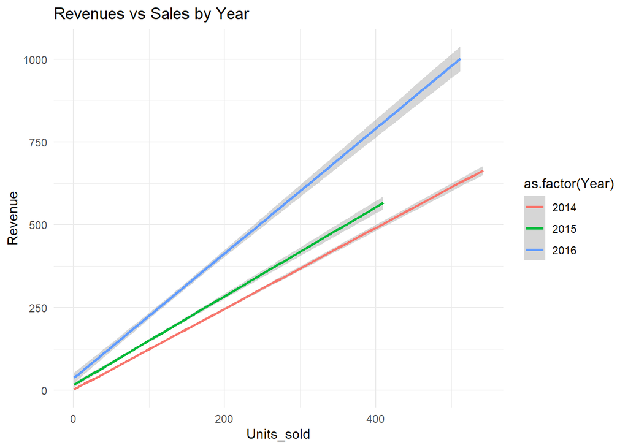

```r
ggplot(df, aes(x = Units_sold, y = Revenue, color = as.factor(Year))) +
  geom_smooth(method = "lm") +
  ggtitle("Revenues vs Sales by Year") +
  theme_minimal()
```

Boxplot - Sales Variability by Year: This boxplot shows sales spread across different years, illustrating any significant year-to-year variability in sales volume.

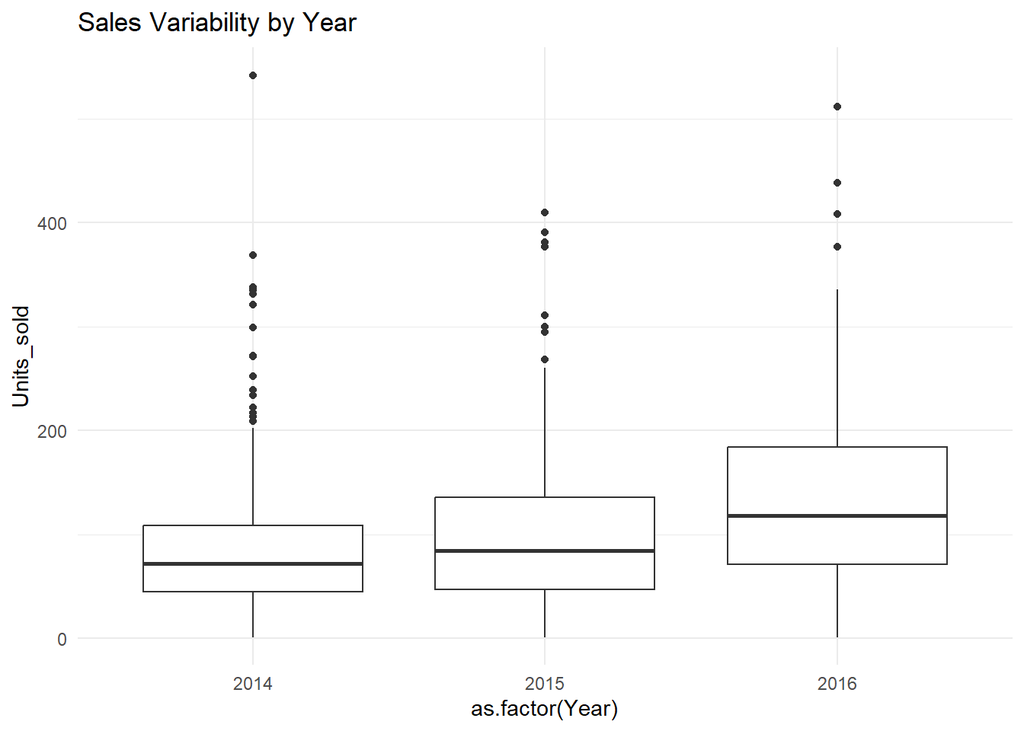

```r
# Boxplot - Sales variability compared by year
ggplot(df, aes(x = as.factor(Year), y = Units_sold)) +
  geom_boxplot() +
  ggtitle("Sales Variability by Year") +
  theme_minimal()
```

KDE Plot - Sales Variability by Year: KDEs further reveal year-based sales trends, highlighting periods of higher or lower sales density.

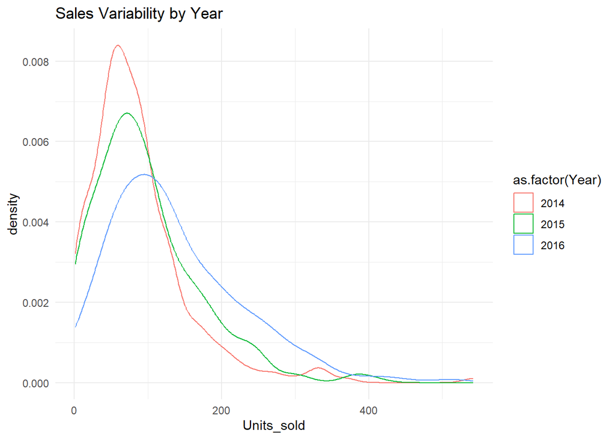

```r
# KDE Plot - Sales variability compared by year
ggplot(df, aes(x = Units_sold, color = as.factor(Year))) +
  geom_density() +
  ggtitle("Sales Variability by Year") +
  theme_minimal()
```

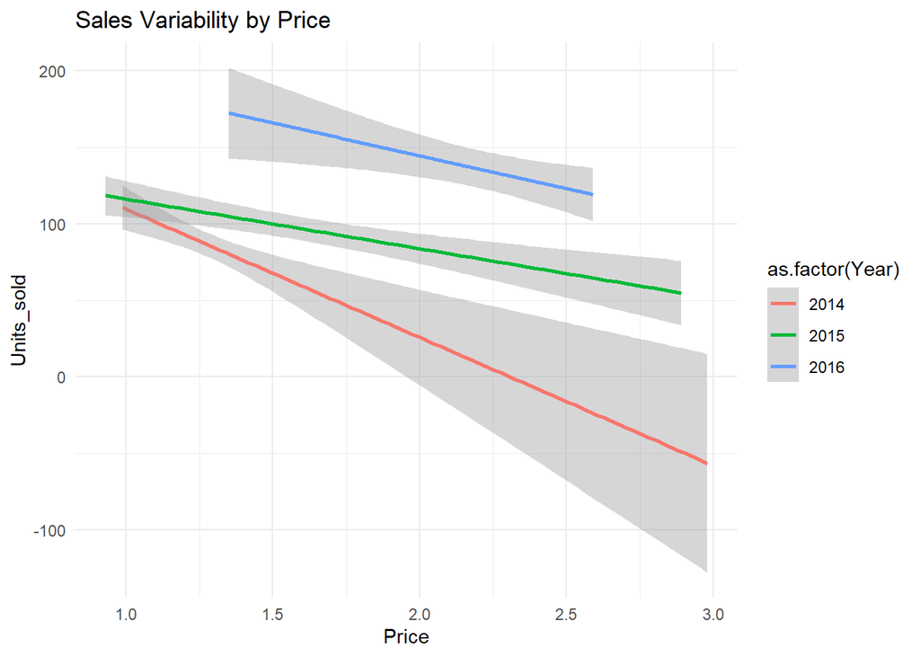

```r
# Analyzing Sales Variability by Price
ggplot(df, aes(x = Price, y = Units_sold, color = as.factor(Year))) +
  geom_smooth(method = "lm") +
  ggtitle("Sales Variability by Price") +
  theme_minimal()
```

### Stock Analysis

Stock Analysis Over Time: Tracking stock over time helps assess if there are predictable cycles in stock replenishment and consumption.

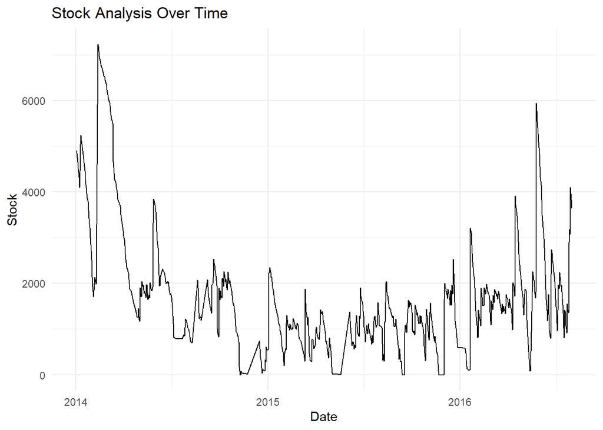

```r
# Stock Analysis over Time
ggplot(df, aes(x = Date, y = Stock)) +
  geom_line() +
  ggtitle("Stock Analysis Over Time") +
  theme_minimal()
```

Stock Density by Year: Density plots of stock can highlight if there are periods with higher or lower stock, possibly indicating seasonal inventory management.

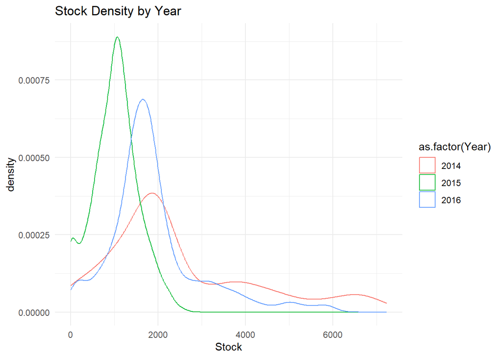

```r
# Stock Density by Year
ggplot(df, aes(x = Stock, color = as.factor(Year))) +
  geom_density() +
  ggtitle("Stock Density by Year") +
  theme_minimal()
```

Sales vs Stock by Year: This regression model on sales vs. stock shows if stock levels impact sales, which may reflect supply limitations or overstocking.

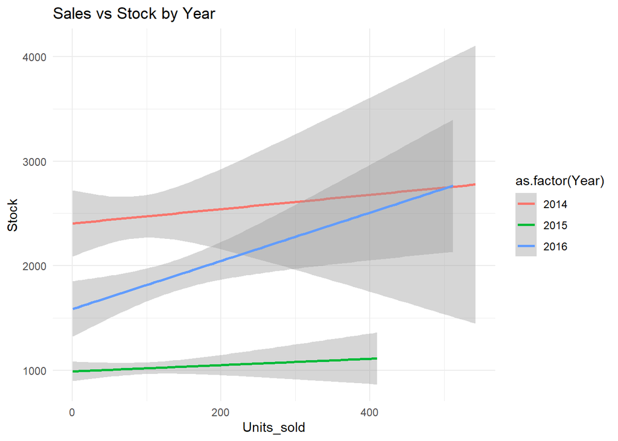

```r
# Linear Model - Sales vs Stock by year
ggplot(df, aes(x = Units_sold, y = Stock, color = as.factor(Year))) +
  geom_smooth(method = "lm") +
  ggtitle("Sales vs Stock by Year") +
  theme_minimal()
```

### Price and Sales Analysis

Sales by Rounded Price: A boxplot analysis with rounded prices reveals how units sold vary at specific price points.

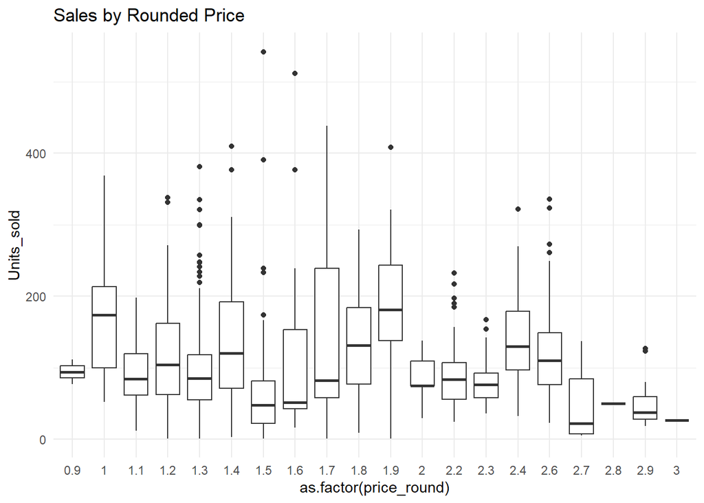

```r
ggplot(df, aes(x = as.factor(price_round), y = Units_sold)) +
  geom_boxplot() +
  ggtitle("Sales by Rounded Price") +
  theme_minimal()
```

Sales vs Stock by Rounded Price: This joint plot shows the relationship between rounded prices and stock in relation to units sold, providing insight into how price points influence inventory management.

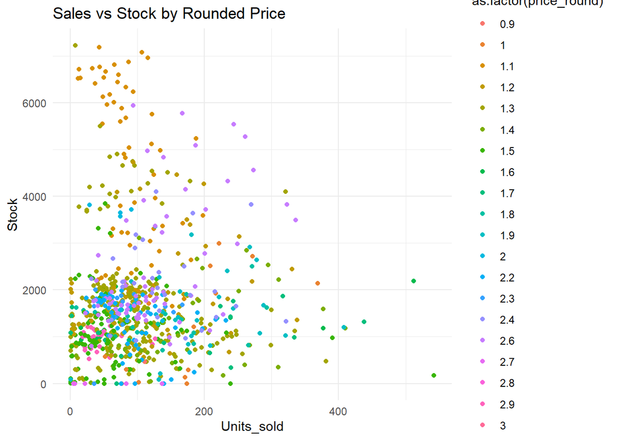

```r
# Joint Plot - Sales vs Stock by Rounded Price
ggplot(df, aes(x = Units_sold, y = Stock, color = as.factor(price_round))) +
  geom_point() +
  ggtitle("Sales vs Stock by Rounded Price") +
  theme_minimal()
```

### Economic Elasticity Analysis

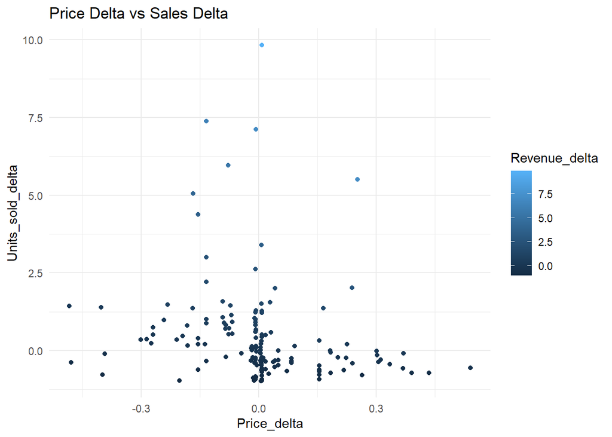

```r
ggplot(pf %>% filter(Price_delta < 0.75 & Units_sold_delta < 10), aes(x = Price_delta, y = Units_sold_delta, color = Revenue_delta)) +
  geom_point() +
  theme_minimal() +
  ggtitle("Price Delta vs Sales Delta")
```

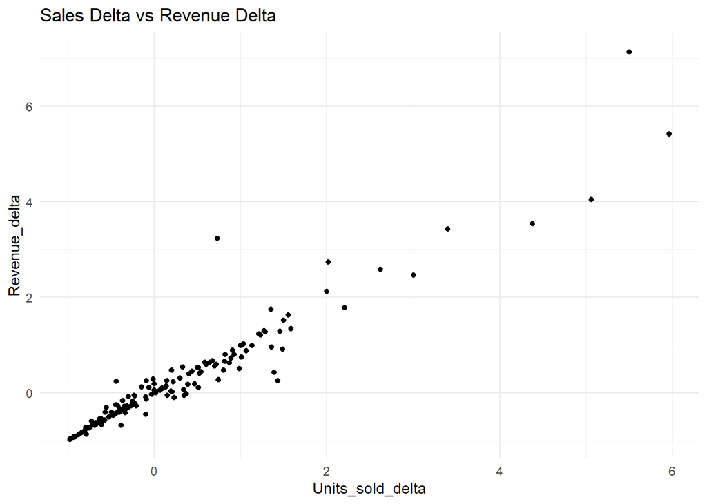

```r
ggplot(pf %>% filter(Units_sold_delta < 7), aes(x = Units_sold_delta, y = Revenue_delta)) +
  geom_point() +
  theme_minimal() +
  ggtitle("Sales Delta vs Revenue Delta")
```

## Regression and ANOVA Models

Regression Analysis - Units Sold: A linear regression model predicts Units_sold based on Price and Stock, giving insights into how these factors contribute to sales volume.

```r
# Linear regression model for 'Units_sold' as a function of 'Price' and 'Stock'
model1 <- lm(Units_sold ~ Price + Stock, data = df)
summary(model1)
```

```
##
## Call:
## lm(formula = Units_sold ~ Price + Stock, data = df)
##
## Residuals:
##     Min      1Q  Median      3Q     Max
## -109.32  -53.27  -16.50   32.36  444.20
##
## Coefficients:
##              Estimate Std. Error t value Pr(>|t|)
## (Intercept) 91.760629   9.886210   9.282   <2e-16 ***
## Price        3.714869   5.221864   0.711    0.477
## Stock        0.002872   0.002013   1.427    0.154
## ---
## Signif. codes:  0 '***' 0.001 '**' 0.01 '*' 0.05 '.' 0.1 ' ' 1
##
## Residual standard error: 78.27 on 822 degrees of freedom
## Multiple R-squared:  0.002878,   Adjusted R-squared:  0.0004517
## F-statistic: 1.186 on 2 and 822 DF,  p-value: 0.3059
```

```r
# ANOVA for the model
anova(model1)
```

```
## Analysis of Variance Table
##
## Response: Units_sold
##            Df  Sum Sq Mean Sq F value Pr(>F)
## Price       1    2063  2063.1  0.3368 0.5619
## Stock       1   12471 12470.9  2.0356 0.1540
## Residuals 822 5035838  6126.3
```

Regression Analysis - Revenue: Another linear model assesses Revenue as a function of Units_sold, quantifying the impact of unit sales on revenue.

```r
# Linear regression model for 'Revenue' as a function of 'Units_sold'
model2 <- lm(Revenue ~ Units_sold, data = df)
summary(model2)
```

```
##
## Call:
## lm(formula = Revenue ~ Units_sold, data = df)
##
## Residuals:
##     Min      1Q  Median      3Q     Max
## -236.93  -34.94  -10.94   28.24  321.79
##
## Coefficients:
##             Estimate Std. Error t value Pr(>|t|)
## (Intercept)  0.73460    3.62668   0.203     0.84
## Units_sold   1.63010    0.02807  58.075   <2e-16 ***
## ---
## Signif. codes:  0 '***' 0.001 '**' 0.01 '*' 0.05 '.' 0.1 ' ' 1
##
## Residual standard error: 63.08 on 823 degrees of freedom
## Multiple R-squared:  0.8038, Adjusted R-squared:  0.8036
## F-statistic:  3373 on 1 and 823 DF,  p-value: < 2.2e-16
```

## Conclusion

Overall, the analysis provides actionable insights for pricing, inventory management, and revenue optimization strategies. By identifying elastic products and adjusting prices accordingly, the store can maximize revenue and reduce stock issues.